# Case Study 1

Group 97 - R Programming

Beccard, Leon - 12133103

Farmohammadi, Pouya - 52116495

Monteiro Oliveira, Guilherme - 12243299

2024-04-15

# 1. Ratio of Fibonacci numbers

## a.

Write two different R functions which return the sequence ri = Fi+1 /Fi for i = 1, . . . , n where Fi is the ith Fibonacci number, once using for and once using while.

For understanding the sequence, it is as follows  
Fibonacci sequence: 0,1,1,2,3,5,8,13,21,…, with 0 as F0

- r1 = F2/F1 = 1/1 = 1
- r2 = F3/F2 = 2/1 = 2
- r3 = F4/F3 = 3/2 = 1.5

**For loop**

```r
fib_ratio_for <- function(n) {
  # Check for bad inputs
  if (n <= 0) {
    stop("Input 'n' cannot be 0 or negative.")
  } else if (n == 1) {
    # Catch case of n = 1 due to a leading error if not implemented
    return(1)
  } else {
    # numeric vector created with length n + 1
    # to store the Fibonacci sequence up to the (n + 1)th element.
    fibonacci <- numeric(n + 1)
    # Assign values (1,1) as first two elements
    fibonacci[1:2] <- c(1, 1)
    # for loop that iterates over the sequence 3:(n + 1)
    # starting from 3 because first two elements are already declared
    for (i in 3:(n + 1)) {
      # Assigning Fibonacci rule to get the next number out of the last two
      fibonacci[i] <- fibonacci[i - 1] + fibonacci[i - 2]
    }
    # Finally calculate the ratio of each fibonacci number
    ratios <- fibonacci[2:(n + 1)] / fibonacci[1:n]
    return(ratios)
  }
}
```

Execute for loop:

```r
fib_ratio_for(5)
```

```
## [1] 1.000000 2.000000 1.500000 1.666667 1.600000
```

**While loop**

```r
fib_ratio_while <- function(n) {
  if (n <= 0) {
    stop("Input 'n' cannot be 0 or negative.")
  } else if (n == 1) {
    return(1)
  } else {
    fibonacci <- numeric(n + 1)
    fibonacci[1:2] <- c(1, 1)
    i <- 3
    while (i <= n + 1) {
      fibonacci[i] <- fibonacci[i - 1] + fibonacci[i - 2]
      i <- i + 1
    }
    ratios <- fibonacci[2:(n + 1)] / fibonacci[1:n]
    return(ratios)
  }
}
```

Execute while loop:

```r
fib_ratio_while(7)
```

```
## [1] 1.000000 2.000000 1.500000 1.666667 1.600000 1.625000 1.615385
```

## b.

Benchmark the two functions for n = 200 and n = 2000 (you can use package microbenchmark or package bench for this purpose). Which function is faster?

```r
# install.packages('microbenchmark')
library(microbenchmark)

microbenchmark(
  fib_ratio_for(200),
  fib_ratio_while(200),
  fib_ratio_for(2000),
  fib_ratio_while(2000)
)
```

```
## Unit: microseconds
##                   expr     min       lq      mean   median       uq       max
##     fib_ratio_for(200)  12.785  14.0490  15.48292  14.5515  15.8200    38.744
##   fib_ratio_while(200)  17.541  18.7530  20.80139  19.7770  20.9985    38.675
##    fib_ratio_for(2000) 121.222 124.3030 287.00179 126.7025 136.7810 15395.603
##  fib_ratio_while(2000) 166.239 169.8655 249.39254 172.2825 184.5720  6811.992
##  neval
##    100
##    100
##    100
##    100
```

**Explanation for statistics given from microbenchmark**  
min: Minimum time it took to execute  
lq: Lower quartile (25th percentile) time it took to execute  
mean: Mean time it took to execute  
median: Median time it took to execute  
uq: Upper quartile (75th percentile) time it took to execute  
max: Maximum time it took to execute  
neval: Number of times each expression was evaluated

**Answer:** As given from the stats, the function using the for loop is faster.

## c.

Plot the sequence for n = 100. For which value n it starts to converge?  
What is the number that it converges to?

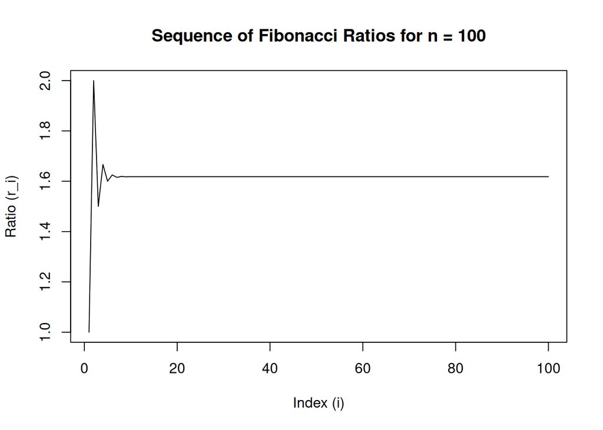

```r
# Calculate the sequence for n = 100
sequence <- fib_ratio_for(100)

# Plot the sequence
plot(sequence, type = "l", xlab = "Index (i)", ylab = "Ratio (r_i)",
     main = "Sequence of Fibonacci Ratios for n = 100")
```

```r
# Get the last 6 values to know what number it converges to
tail(sequence)
```

```
## [1] 1.618034 1.618034 1.618034 1.618034 1.618034 1.618034
```

```r
# Get the last 6 values to know what number it converges to
head(sequence)
```

```
## [1] 1.000000 2.000000 1.500000 1.666667 1.600000 1.625000
```

**Answer:** It converges towards the 1.618034. The so-called golden ratio. It starts converging towards 1.61 at around n=7.

# 2. Gamma function

Write a function to compute the following for n a positive integer using the gamma function in base R.

```r
# Function to compute rho_n using gamma function
compute_rho <- function(n) {
  if (n >= 2) {
    numerator <- gamma((n - 1)/2)
    denominator <- gamma(1/2) * gamma((n - 2)/2)
    return(numerator / denominator)
  } else {
    stop("n must be bigger than 2")
  }
}
```

### b. Observing behavior for n = 2000

Try n = 2000. What do you observe? Why do you think the observed behavior happens?

```r
n <- 2000
rho_2000 <- compute_rho(n)
print(rho_2000)
```

```
## [1] NaN
```

### c. Implementation for large values of n

Write an implementation which can also deal with large values of n > 1000.

```r
# Function to compute rho_n for large values of n
compute_large_rho <- function(n) {
  if (n >= 2) {
    # Handling large values of n using log-gamma
    numerator <- lgamma((n - 1)/2)
    denominator <- lgamma(1/2) + lgamma((n - 2)/2)
    return(exp(numerator - denominator))
  } else {
    stop("n must be bigger than 2")
  }
}

# Testing the functions
n <- 1001
print(paste("Ouput of normal function ",compute_rho(n)))
```

```
## [1] "Ouput of normal function  NaN"
```

```r
print(paste("Ouput of optimized function for large N ",compute_large_rho(n)))
```

```
## [1] "Ouput of optimized function for large N  12.6061981025774"
```

### d. Plotting ρn/√n for different values of n

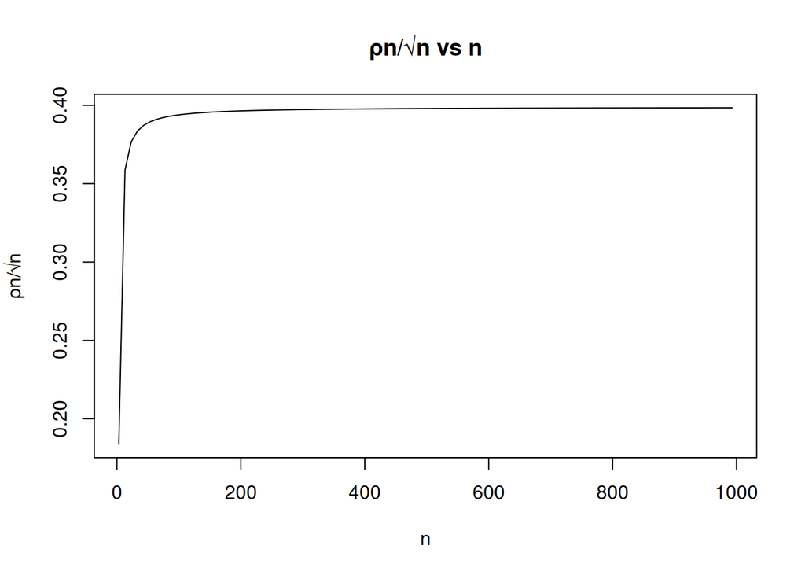

```r
n_values <- seq(3, 1000, by = 10)
rho_values <- sapply(n_values, function(n) compute_large_rho(n) / sqrt(n))
plot(n_values, rho_values, type = 'l', xlab = 'n', ylab = 'ρn/√n', main = 'ρn/√n vs n')
```

# 3. The golden ratio

Write an R function which computes Φn+1 using the recursion above (go up to n = 1000) .

```r
# a. Computing Φn+1 using recursion
phi_recursive <- function(n) {

  if(n < 0) {
    stop("No negative numbers")
  }


  if (n == 0) {
    return((sqrt(5) + 1)/2)
  } else if (n == 1) {
    return((sqrt(5) + 3)/2)
  } else {
    return(phi_recursive(n - 1) + phi_recursive(n - 2))
  }
}

phi_recursive(25)
```

```
## [1] 271443
```

```r
# b. Computing Φn+1 using power operator
phi_power <- function(n) {
  phi <- (sqrt(5) + 1)/2
  return(phi^(n + 1))
}
phi_power(25)
```

```
## [1] 271443
```

```r
# c. Comparing results
# n_values <- c(12, 60, 120, 300)
n_values <- c(12)
for (n in n_values) {
  result_a <- phi_recursive(n)
  result_b <- phi_power(n)

  # Using == operator
  comparison1 <- result_a == result_b

  # Using all.equal function
  comparison2 <- all.equal(result_a, result_b)

  cat("For n =", n, "\n")
  cat("Using == operator:", comparison1, "\n")
  cat("Using all.equal function:", comparison2, "\n\n")
}
```

```
## For n = 12
## Using == operator: FALSE
## Using all.equal function: TRUE
```

As shown in the output, when using the == operator, the comparison returns FALSE for n=12 On the other side using the all.equal function, the comparison returns TRUE. This behaviour should be the same for the other values of n. Due to time limitations, this program had to be quit after three hours running.

The reason for the difference when using the == operator is due to the way floating-point arithmetic is handled in R. Floating-point arithmetic can introduce small rounding errors, causing direct comparisons using == to fail, even if the values are very close.

The all.equal function, on the other hand, compares the values with tolerance, allowing for small differences due to floating-point arithmetic. Therefore, it returns TRUE for values that are very close.

# 4. Game of craps

A variation of game of craps is played as follows. The player rolls a die and if they roll a 6, they immediately wins. If a 1 is rolled, they immediately loses. If a 2, 3, 4, or 5 is rolled, then this number becomes their “point number.’ ’ The player then has up to three more rolls of the die to roll their point number again. If they do, they win otherwise they lose. Write a program in R to simulate a game of craps. Explain the steps of your program. If the code is not explained, no points will be earned.

```r
# Define the function for a game of crabs
game_of_craps <- function(){
    # Function to get a random number between 1 and 6 i.e. rolling the dice once
    dice_number <- floor(runif(1, min=1, max=7))
    # check for win or lose condition in first attempt
    if (dice_number == 1){
      return("Sorry, you lost!")
    }
    else if (dice_number == 6){
      return("Yeah, you won in the first attempt!")
    }
    else {
      # for loop to have three more attempts to roll the same 'point number'
      for (i in 1:3){
        # Function to get a random number between 1 and 6 i.e. rolling the dice once
        new_dice_number <- floor(runif(1, min=1, max=7))
        # Check for same 'point number'
        if (dice_number == new_dice_number){
          return("Yeah, you won rolling the same 'point number' again!")
        }
    }
  }
  return("Sorry, you lost after three more attempts!")
}

# Execute function i.e. one simulation of the game
game_of_craps()
```

```
## [1] "Sorry, you lost after three more attempts!"
```

# 5. Readable and efficient code

Read over the code below.

```r
set.seed(1)
x <- rnorm(1000)
y <- 2 + x + rnorm(1000)
df <- data.frame(x, y)

cat("Step", 1, "\n")
fit1 <- lm(y ~ x, data = df[-(1:250),])
p1 <- predict(fit1, newdata = df[(1:250),])
r <- sqrt(mean((p1 - df[(1:250),"y"])^2))

cat("Step", 2, "\n")
fit2 <- lm(y ~ x, data = df[-(251:500),])
p2 <- predict(fit2, newdata = df[(251:500),])
r <- c(r, sqrt(mean((p2 - df[(251:500),"y"])^2)))

cat("Step", 3, "\n")
fit3 <- lm(y ~ x, data = df[-(501:750),])
p3 <- predict(fit3, newdata = df[(501:750),])
r <- c(r, sqrt(mean((p3 - df[(501:750),"y"])^2)))

cat("Step", 4, "\n")
fit4 <- lm(y ~ x, data = df[-(751:1000),])
p4 <- predict(fit4, newdata = df[(751:1000),])
r <- c(r, sqrt(mean((p4 - df[(751:1000),"y"])^2)))
r
```

## Solution

### a. Explain the code

Each step consist of r selecting different sections of the data frame df with a proportion of 75% to 25% for training and testing respectively and calculate the root mean square error for each step. The error for each steps are 1.0249956, 0.9952113, 1.06855, 1.0707264 and the biggest gap between the errors is 0.0755151, what is doesn’t looks like outstanding.

### b. Readability

From the code we can notice a few things:

- The code is repeating itself a few times and run it in a loop or call functions to avoid code repetition would make it more readable.
- The code could write more comments in the code to give us an abstraction of what he is planning to do and inline comment to give us specific details, like the definition of the variable x.
- Use meaningful names can make it easier to understand the code, like *pred1*, instead of *p1*.

### c. Wrap Function

Change the code according to a. and wrap it in a function. This function should have at most 10 lines (without adding commands to more lines such as x <- 1; y <- 2. Such commands will count as 2 lines!). Check that the function called on the same input outputs the same as the provided code.

```r
# Define the function

linear_models <- function(df, formula, steps = 4) {
  # Create an empty vector to store the errors
  r <- numeric()
  step = nrow(df)/steps
  # Loop through the steps
  for (i in 1:steps) {
    cat("Step", i, "\n")
    section <- ((i-1)*step+1):(i*step)
    fit <- lm(formula, data = df[-section,]) # Fit the model
    p <- predict(fit, newdata = df[section,]) # Predict the model
    r <- c(r, sqrt(mean((p - df[section,"y"])^2)))
  }
  return(r)
}

set.seed(1)
x <- rnorm(1000)
y <- 2 + x + rnorm(1000)
df <- data.frame(x, y)

# Execute the function

linear_models(df, y ~ x)
```

```
## Step 1
## Step 2
## Step 3
## Step 4
## [1] 1.0249956 0.9952113 1.0685500 1.0707264
```

# 6. Measuring and improving performance

Have a look at the code of the function below. It is a function for performing a Kruskal Wallis test, a robust non-parametric method for testing whether samples come from the same distribution. (Note: we assume no missing values are present in x).

```r
kwtest <- function (x, g, ...)
{
  if (is.list(x)) {
    if (length(x) < 2L)
      stop("'x' must be a list with at least 2 elements")
    if (!missing(g))
      warning("'x' is a list, so ignoring argument 'g'")
    if (!all(sapply(x, is.numeric)))
      warning("some elements of 'x' are not numeric and will be coerced to numeric")
    k <- length(x)
    l <- lengths(x)
    if (any(l == 0L))
      stop("all groups must contain data")
    g <- factor(rep.int(seq_len(k), l))
    x <- unlist(x)
}
else {
  if (length(x) != length(g))
    stop("'x' and 'g' must have the same length")
  g <- factor(g)
  k <- nlevels(g)
  if (k < 2L)
    stop("all observations are in the same group")
}
n <- length(x)
if (n < 2L)
  stop("not enough observations")
r <- rank(x)
TIES <- table(x)

STATISTIC <- sum(tapply(r, g, sum)^2/tapply(r, g, length))
STATISTIC <- ((12 * STATISTIC/(n * (n + 1)) - 3 * (n + 1))/(1 -
  sum(TIES^3 - TIES)/(n^3 - n)))
PARAMETER <- k - 1L

PVAL <- pchisq(STATISTIC, PARAMETER, lower.tail = FALSE)
names(STATISTIC) <- "Kruskal-Wallis chi-squared"
names(PARAMETER) <- "df"
RVAL <- list(statistic = STATISTIC, parameter = PARAMETER,
  p.value = PVAL, method = "Kruskal-Wallis rank sum test")
return(RVAL)
}
```

## Solution

### **a. Pseudo code**

```r
kwtest_pseudo <- function (x, g, ...)
{
  if x is a list {
    if x has less than 2 elements
      Do not continue with the code and inform the user
    if g is provided
      Give a warning to the user that g will be ignored
    if all the elemensts of x are not numeric
      Warns the users that some elements are not numeric and will be converted
      to numeric
    k <- length(x)
    l <- lengths(x)
    if any element of x is 0
      Stop and inform that all the groups should contain data
    g <- factor(rep.int(seq_len(k), l))
    x <- unlist(x)
  }
  if x is not a list {
    if the length of x and g are different
      Stops and inform the user x and g should be the same length
    g <- factor(g)
    k <- nlevels(g)
    if there are less than 2 groups in g
      Stop and inform the user
  }
  n <- length(x)
  if x length is less than 2
    Stop and inform about the lack of observations
  r <- rank(x)
  TIES <- table(x)
  STATISTIC <- Calculate the Kruskal-Wallis statistic
  PARAMETER <- degree of freedom
  PVAL <- pchisq(STATISTIC, PARAMETER, lower.tail = FALSE)
  names(STATISTIC) <- "Kruskal-Wallis chi-squared"
  names(PARAMETER) <- "df"
  RVAL <- list(statistic = STATISTIC, parameter = PARAMETER,
  p.value = PVAL, method = "Kruskal-Wallis rank sum test")
  return(RVAL)

}
```

### **b. Example call**

```r
# Example with list

x_list <- list(
  group1 = c(1, 3, 4, 2),
  group2 = c(2, 6, 1, 7)
)

# Example with vector

x_vector <- c(1, 3, 4, 2, 2, 6, 1, 7)
g_vector <- c(1, 1, 1, 1, 2, 2, 2, 2) # group labels

result_list <- kwtest(x_list)
result_vector <- kwtest(x_vector, g_vector)

print("Result using x as list:")
print(result_list)

print("Result using x as vector:")
print(result_vector)
```

```
## [1] "Result using x as list:"
## $statistic
## Kruskal-Wallis chi-squared
##                  0.3414634
##
## $parameter
## df
##  1
##
## $p.value
## [1] 0.5589857
##
## $method
## [1] "Kruskal-Wallis rank sum test"
##
## [1] "Result using x as vector:"
## $statistic
## Kruskal-Wallis chi-squared
##                  0.3414634
##
## $parameter
## df
##  1
##
## $p.value
## [1] 0.5589857
##
## $method
## [1] "Kruskal-Wallis rank sum test"
```

### **c. kwtest faster**

```r
kwtest_fast <- function(x, g, ...) {
  if (!is.numeric(x) | !is.numeric(g)) {
    stop("x and g must be numeric vectors")
  }

  if (length(x) != length(g)) {
    stop("x and g must have the same length")
  }

  number_groups <- nlevels(factor(g))
  N <- length(x)

  if (number_groups < 2L){
    stop("nlevels(g) < 2 shows all observations are in the same group")
  }

  if (N < 2L)
    stop("length(x) has not enough observations")

  number_groups <- nlevels(factor(g))
  obs_group <- length(unique(g))
  r <- rank(x)
  r_group_avg <- tapply(r, g, sum)/obs_group
  r_avg <- (N + 1)/2

  H_num <-(N - 1) * sum(obs_group * (r_group_avg - r_avg)**2)
  H_dem <- sum((r - r_avg)**2)

  H <- H_num/H_dem

  pval <- pchisq(H, obs_group - 1, lower.tail = FALSE)

  return(pval)

}

kwtest_fast(x_vector, g_vector)
```

```
## [1] 0.0001392551
```

### **d. Multiple experiments using apply function**

```r
set.seed(1234)
m <- 1000 # number of repetitions
n <- 50
# number of individuals
X <- matrix(rt(m * n, df = 10), nrow = m)
grp <- rep(1:3, c(20, 20, 10))


kwtest_mult <- function(X, grp) {
  res <- apply(X, 1, function(x) kwtest_fast(x, grp))
}

# Returns all the statistics from res

res <- kwtest_mult(X, grp)

# Extract the p-values

p_values <- sapply(res, function(x) x)
```

### **e. Multiple experiments using for loop**

```r
kwtest_matrix2 <- function(X, g) {
  if (!is.matrix(X)) {
    stop("X must be a matrix.")
  }
  if (!is.numeric(g)) {
    stop("g must be a numeric vector")
  }
  if (ncol(X) != length(g)) {
    stop("Number of cols X of matrix have to be as long as length of vector g")
  }
  m <- nrow(X)
  test_statistics <- numeric(m)

  for (i in 1:m) {
    # Take data from each row
    experiment_data <- X[i,]
    # Calculate Chi-Square value from Kruskal wallis test and store it in vector
    test_statistics[i] = kwtest_fast(experiment_data, g)
  }

  return(test_statistics)

}
```

### **f. Benchmarking**

```r
library(microbenchmark)

# For a better overview set random data from above here again
set.seed(1234)
m <- 1000 # number of repetitions
n <- 50
X <- matrix(rt(m * n, df = 10), nrow = m)
grp <- rep(1:3, c(20, 20, 10))

# Benchmark the two functions
benchmarks <- microbenchmark(
  apply_approach = kwtest_mult(X, grp),
  loop_approach = kwtest_matrix2(X, grp),
  times = 10
)

# Print the benchmarks
print(benchmarks)
```

```
## Unit: milliseconds
##            expr      min       lq     mean   median       uq      max neval
##  apply_approach 72.49299 73.77762 75.15048 75.37493 76.32704 77.34967    10
##   loop_approach 71.90807 72.49144 73.99361 73.43288 74.65271 77.67587    10
```

As shown from the statistics, the loop approach is a little bit faster than the apply approach, which is against the expectations since the apply function is supposed to be more efficient than the for loop approach.

### **g. Vectorizing**

```r
library(microbenchmark)

# For a better overview set random data from above here again
set.seed(1234)
m <- 1000 # number of repetitions
n <- 50
X <- matrix(rt(m * n, df = 10), nrow = m)
grp <- rep(1:3, c(20, 20, 10))

kwtest_vectorize <- function(X, grp) {
  #?Vectorize
  #print(grp)
  # vectorized_kwtest <- Vectorize(kwtest_fast, vectorize.args = "X")

  #print(vectorized_kwtest)
  # res <- vectorized_kwtest(X, grp)
  # return(res)

  res <- mapply(kwtest, split(X, seq(nrow(X))), MoreArgs = list(grp))
  return(res)
}

# Benchmark the two functions
benchmarks <- microbenchmark(
  apply_approach = kwtest_mult(X, grp),
  loop_approach = kwtest_matrix2(X, grp),
  vectorize_approach = kwtest_vectorize(X, grp),
  times = 10
)

# Print the benchmarks
print(benchmarks)
```

```
## Unit: milliseconds
##                expr       min        lq      mean    median        uq       max
##      apply_approach  70.57850  75.49098  77.73288  77.59207  81.79903  82.53393
##       loop_approach  74.95091  75.49853  78.86293  77.83301  80.56589  87.96389
##  vectorize_approach 177.61969 183.93899 190.14456 188.01529 192.84367 217.19504
##  neval
##     10
##     10
##     10
```